# Actividad 3

2024-04-19

#### **Equipo 1**

- Gabriela Cantú Sánchez A01735256
- Alexa Mariana Marin Villar A00831342
- Ana Estefanía López Alanis A01284416
- Astrid Paola Gonzalez Diaz A00830114

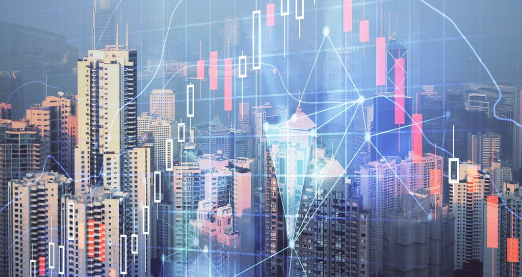

## **Introducción**

### **Diferencias entre los modelo de regresión global y local**

La principal diferencia entre los modelos de regresión global y los modelos de regresión local se encuntre en que los modelos globales asumen que los **coeficientes permanecen constantes** en todo el espacio, mientras que los modelos de regresión local permiten que los **coeficientes varíen** en función de la ubicación geográfica, lo que lo hace más flexible y adecuado para capturar patrones espaciales complejos.

Investigando mas a fondo se encontraron las siguientes diferencias por modelo:

Modelos de Regresión Global

Modelos de Regresión Local

- Se estima un solo modelo para todos los datos sin tomar en cuenta la variación espacial en los coeficientes.
- Asume que los coeficientes son constantes en todas las localidades, lo que puede no ser realista en caso de que haya heterogeneidad espacial.
- Para cada localidad o vecindario se ajusta un modelo separado para tomar en cuenta la variabilidad.
- Permite que los coeficientes varíen en función de la ubicación, tomando en cuenta la heterogeneidad espacial en los datos.
- Es una técnica que toma en cuenta variables no estacionarias.
- Reduce autocorrelación espacial en los residuales.

## **Modelo de Regresión Global No Espacial**

En los modelos estimados en la actividad 2, se tomaron en cuenta aquellas variables que mostraron un índice de correlación alto con relación a la variable de **nueva inversión extranjera**.

Después de tomar en cuenta varios parámetros y realizar las comparaciones y pruebas debidas, obtuvimos que el modelo mejor estimado fue el de **efectos fijos para datos panel**, incluyendo la transformación logarítmica de densidad poblacional.

```r
#Transformación a datos panel
nearshoring_pd<- pdata.frame(nearshoring, index = c("state", "year"))
nearshoring_pd<- nearshoring_pd %>% dplyr::select(-state, -year)

#Modelo no espacial
m1_no_espacial <- plm(new_fdi_real_mxn ~ real_wage + log(pop_density) + region_b + lq_primary + employment, data=nearshoring_pd, model="within", effect="time")
summary(m1_no_espacial)
```

```
## Oneway (time) effect Within Model
##
## Call:
## plm(formula = new_fdi_real_mxn ~ real_wage + log(pop_density) +
##     region_b + lq_primary + employment, data = nearshoring_pd,
##     effect = "time", model = "within")
##
## Balanced Panel: n = 32, T = 16, N = 512
##
## Residuals:
##      Min.   1st Qu.    Median   3rd Qu.      Max.
## -40405.40  -4317.10   -764.85   2826.30  58698.58
##
## Coefficients:
##                    Estimate Std. Error t-value  Pr(>|t|)
## real_wage            96.899     10.380  9.3350 < 2.2e-16 ***
## log(pop_density)   2179.818    356.212  6.1194 1.922e-09 ***
## region_b            209.304    313.524  0.6676  0.504713
## lq_primary         -203.136    461.213 -0.4404  0.659814
## employment       -84783.113  30624.957 -2.7684  0.005846 **
## ---
## Signif. codes:  0 '***' 0.001 '**' 0.01 '*' 0.05 '.' 0.1 ' ' 1
##
## Total Sum of Squares:    5.3102e+10
## Residual Sum of Squares: 3.3979e+10
## R-Squared:      0.36011
## Adj. R-Squared: 0.33405
## F-statistic: 55.2645 on 5 and 491 DF, p-value: < 2.22e-16
```

Los resultados de este modelo nos indican que es estadísticamente significativo, y que su especificación logra explicar en un 33.4% la variabilidad de la varaiable dependiente.

## **Modelo de Regresión de Global Espacial**

### *Matriz de Conectividad*

```r
#Spatial weight matrix (SWM)

queen_swm  <- poly2nb(mx_state_map, queen=T)
queen_sswm <- nb2listw(queen_swm, style="W", zero.policy = TRUE)
summary(queen_swm)
```

```
## Neighbour list object:
## Number of regions: 32
## Number of nonzero links: 138
## Percentage nonzero weights: 13.47656
## Average number of links: 4.3125
## Link number distribution:
##
## 1 2 3 4 5 6 7 8 9
## 1 6 6 6 5 2 3 2 1
## 1 least connected region:
## 31 with 1 link
## 1 most connected region:
## 8 with 9 links
```

```r
rook_swm  <- poly2nb(mx_state_map, queen=F)
rook_sswm <- nb2listw(rook_swm, style="W", zero.policy = TRUE)
summary(rook_swm)
```

```
## Neighbour list object:
## Number of regions: 32
## Number of nonzero links: 130
## Percentage nonzero weights: 12.69531
## Average number of links: 4.0625
## Link number distribution:
##
## 1 2 3 4 5 6 7 8
## 1 6 7 7 3 4 3 1
## 1 least connected region:
## 31 with 1 link
## 1 most connected region:
## 20 with 8 links
```

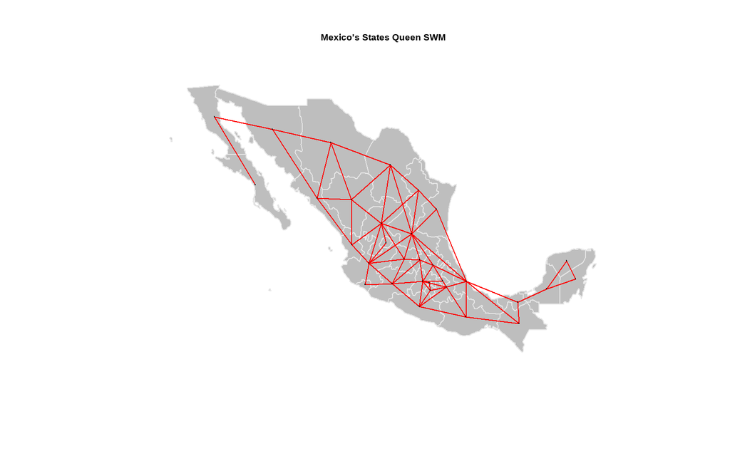

```r
mx_state_map_a <- as(mx_state_map, "Spatial")
mx_state_map_centroid <- coordinates(mx_state_map_a)
plot(mx_state_map_a,border="blue",axes=FALSE,las=1, main="Mexico's States Queen SWM")
plot(mx_state_map_a,col="grey",border=grey(0.9),axes=T,add=T)
plot(queen_sswm,coords=mx_state_map_centroid,pch=19,cex=0.1,col="red",add=T)
```

Con los resultados de queen, se puede observar que sí existen enlaces no nulos y un porcentaje de 13.4 de pesos no nulos. Al hacerlo con rook se encuentran 130 enlaces no nulos y un porcentaje de 12.6. A pesar de ser porcentajes relativamente bajos, se valida el por qué es importante hacer un análisis espacial.

### *Especificación del Modelo*

Anteriormente se llevaron a cabo pruebas **Moran I** para identificar las variables que presentan autocorrelacion espacial significativa. Tomando en cuenta esto, se seleccionaron las siguientes variables para empezar a estimar los modelos espaciales: *Real Average Month Income, Log Population Density, Location Quotient Primary, Business Activity y College Education*.

Después de comparar los distintos modelos especificados en la actividad 2, se seleccionó como mejor modelo de regresión global el SEM (Spatial Error Model).

```r
#Datos
panel_model <- new_fdi_real_mxn ~ real_ave_month_income + log(pop_density) + lq_primary + business_activity + college_education

#Modelo Espacial SEM
m2_sem <- spml(panel_model, data = nearshoring_pd, index = c("state","year"), queen_sswm, model="within", spatial.error="b", lag=FALSE) # spatial autoregressive
summary(m2_sem)
```

```
## Spatial panel fixed effects error model
##
##
## Call:
## spml(formula = panel_model, data = nearshoring_pd, index = c("state",
##     "year"), listw = queen_sswm, model = "within", lag = FALSE,
##     spatial.error = "b")
##
## Residuals:
##      Min.   1st Qu.    Median   3rd Qu.      Max.
## -58619.89  -2376.51   -530.54   1400.35  51546.69
##
## Spatial error parameter:
##     Estimate Std. Error t-value Pr(>|t|)
## rho 0.149169   0.056319  2.6486 0.008082 **
##
## Coefficients:
##                          Estimate  Std. Error t-value Pr(>|t|)
## real_ave_month_income     0.77694     0.81174  0.9571   0.3385
## log(pop_density)        188.85587 10115.71978  0.0187   0.9851
## lq_primary              571.58007  1004.54731  0.5690   0.5694
## business_activity      4006.91320  4111.88614  0.9745   0.3298
## college_education     -4769.85704 10431.43235 -0.4573   0.6475
```

## **Identificar Autocorrelación Espacial en los Residuales Ɛi para cada Modelo**

```r
unidos <- merge(mx_state_map, nearshoring_pd, by.x = "OBJECTID", by.y = "state_id")
swm2 <- poly2nb(unidos, queen = TRUE)
sswm2 <- nb2listw(swm2, style = "W", zero.policy = TRUE)
```

```r
#Modelo no espacal
noespacial_residuales<-residuals(m1_no_espacial)

noespacial_residuales_moran <- moran.test(noespacial_residuales, listw = sswm2)
print(noespacial_residuales_moran)
```

```
##
##  Moran I test under randomisation
##
## data:  noespacial_residuales
## weights: sswm2
##
## Moran I statistic standard deviate = 13.563, p-value < 2.2e-16
## alternative hypothesis: greater
## sample estimates:
## Moran I statistic       Expectation          Variance
##      8.725506e-02     -1.956947e-03      4.326743e-05
```

```r
#Modelo espacal
sem_residuales<-residuals(m2_sem)

sem_residuales_moran <- moran.test(sem_residuales, listw = sswm2)
print(sem_residuales_moran)
```

```
##
##  Moran I test under randomisation
##
## data:  sem_residuales
## weights: sswm2
##
## Moran I statistic standard deviate = 0.44122, p-value = 0.3295
## alternative hypothesis: greater
## sample estimates:
## Moran I statistic       Expectation          Variance
##      9.131123e-04     -1.956947e-03      4.231213e-05
```

De acuerdo a los resultados presentados, para el modelo de regresión no espacial si existe una autocorrelación espacial baja positiva y estadísticamente significativa entre los residuales, lo cual respalda la necesidad de estimar un modelo de regresión espacial. Por otro lado se observó que no existe autocorrelación espacial significativa entre los residuales del modelo de regresión espacial global, lo cual indica los residuales tienen un comportamiento aleatorio que es lo que se busca.

## **Modelo de Regresión de Local Espacial**

Para los modelos en este apartado se decidio utilizar dos bases de datos, en la data reciente se incluye una base de datos de corte transversal utilizando la mediana del 2016 al 2021. En cuanto a la data antigua se incluye de la misma manera pero utilizando la mediana del 2006 al 2011.

```r
queen_swm2  <- poly2nb(mx_state_map, queen=T)
queen_sswm2 <- nb2listw(queen_swm, style="W", zero.policy = TRUE)
summary(queen_swm2)
```

```
## Neighbour list object:
## Number of regions: 32
## Number of nonzero links: 138
## Percentage nonzero weights: 13.47656
## Average number of links: 4.3125
## Link number distribution:
##
## 1 2 3 4 5 6 7 8 9
## 1 6 6 6 5 2 3 2 1
## 1 least connected region:
## 31 with 1 link
## 1 most connected region:
## 8 with 9 links
```

```r
rook_swm2  <- poly2nb(mx_state_map, queen=F)
rook_sswm2 <- nb2listw(rook_swm, style="W", zero.policy = TRUE)
summary(rook_swm2)
```

```
## Neighbour list object:
## Number of regions: 32
## Number of nonzero links: 130
## Percentage nonzero weights: 12.69531
## Average number of links: 4.0625
## Link number distribution:
##
## 1 2 3 4 5 6 7 8
## 1 6 7 7 3 4 3 1
## 1 least connected region:
## 31 with 1 link
## 1 most connected region:
## 20 with 8 links
```

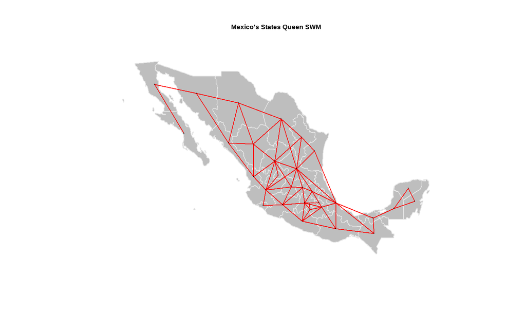

```r
mx_state_map_a2 <- as(mx_state_map, "Spatial")
mx_state_map_centroid2 <- coordinates(mx_state_map_a2)
plot(mx_state_map_a2,border="blue",axes=FALSE,las=1, main="Mexico's States Queen SWM")
plot(mx_state_map_a2,col="grey",border=grey(0.9),axes=T,add=T)
plot(queen_sswm2,coords=mx_state_map_centroid2,pch=19,cex=0.1,col="red",add=T)
```

### *GWR - Local Regression Model 2016 - 2021*

```r
gwr_model # gwr estimated results
```

```
##    *                       Package   GWmodel                             *
##    Program starts at: 2024-04-19 21:11:22.696244
##    Call:
##    gwr.basic(formula = mediana_IED_flujos ~ medianrealwage + log(mediana_densitypob) +
##     medianlqprimaryyy + medianemployment, data = state_gwrdata,
##     bw = bw1, adaptive = T)
##
##    Dependent (y) variable:  mediana_IED_flujos
##    Independent variables:  medianrealwage mediana_densitypob medianlqprimaryyy medianemployment
##    Number of data points: 32
##    *                    Results of Global Regression                     *
##
##    Call:
##     lm(formula = formula, data = data)
##
##    Residuals:
##    Min     1Q Median     3Q    Max
## -10417  -2682    319   3215  15646
##
##    Coefficients:
##                              Estimate Std. Error t value Pr(>|t|)
##    (Intercept)               82930.21  102323.27   0.810  0.42476
##    medianrealwage               94.75      28.85   3.284  0.00283 **
##    log(mediana_densitypob)    2397.72     870.12   2.756  0.01036 *
##    medianlqprimaryyy          -729.46    1524.91  -0.478  0.63624
##    medianemployment        -120972.25  105479.26  -1.147  0.26149
##
##    ---Significance stars
##    Signif. codes:  0 '***' 0.001 '**' 0.01 '*' 0.05 '.' 0.1 ' ' 1
##    Residual standard error: 5669 on 27 degrees of freedom
##    Multiple R-squared: 0.6219
##    Adjusted R-squared: 0.5659
##    F-statistic:  11.1 on 4 and 27 DF,  p-value: 1.862e-05
##    ***Extra Diagnostic information
##    Residual sum of squares: 867807645
##    Sigma(hat): 5378.375
##    AIC:  650.5159
##    AICc:  653.8759
##    BIC:  648.1047
##    *          Results of Geographically Weighted Regression              *
```

[output cut: 17 more lines]

```
##    log(mediana_densitypob)    3552.19
##    medianlqprimaryyy          1493.47
##    medianemployment        -102316.15
##    ************************Diagnostic information*************************
##    Number of data points: 32
##    Effective number of parameters (2trace(S) - trace(S'S)): 9.613917
##    Effective degrees of freedom (n-2trace(S) + trace(S'S)): 22.38608
##    AICc (GWR book, Fotheringham, et al. 2002, p. 61, eq 2.33): 656.0016
##    AIC (GWR book, Fotheringham, et al. 2002,GWR p. 96, eq. 4.22): 637.5043
##    BIC (GWR book, Fotheringham, et al. 2002,GWR p. 61, eq. 2.34): 625.4796
##    Residual sum of squares: 652750511
##    R-square value:  0.7156364
##    Adjusted R-square value:  0.5878033
##
##    Program stops at: 2024-04-19 21:11:22.700021
```

El modelo sería significativo porque el valor de p es menor al 5%. En cuanto a las variables, podemos observar como significativas la mediana del salario promedio y el logaritmo de la mediana de la densidad de población. Ambos coeficientes son positivos, indicando que mientras estas variables incrementen, la IED también aumentará. Es posible observar que el logaritmo de la variable de densidad de población tiene un mayor peso en la predicción de la Nueva IED que el salario real. Se encuentra una R cuadrada ajustada de 0.56, lo que indica que el 56% de la variabilidad de la nueva inversión extranjera directa puede ser explicada por el modelo anterior.

A través de los coeficientes se puede observar el impacto de las variables en la inversión extranjera directa en los diferentes estados. El efecto del salario real es relativamente bajo ya que el máximo efecto que tiene es de 134 sobre la variable de IED nueva. Se puede observar que el mínimo efecto del logaritmo de la densidad de población en la IED nueva será de 1290, con una mediana de 2297, lo cual es alto, variable que salió significativa anteriormente. En cuanto a la mediana del coeficiente del sector primario también se puede observar un valor relativamente bajo. Sería importante explorar a futuro el por qué los coeficientes del mínimo y el primer cuartil, son negativos (indicando una relación inversa) y los siguientes positivos, sería posible que en algunos estados se encuentra una relación negativa entre estas variables. Por último, la mediana del empleo indica una relación inversa entre las variables con un peso muy grande. Esto indicaría que a mayor empleabilidad menor inversión extranjera directa nueva. Algunos de los estimados cambian significativamente entre el modelo global y el GWR. El AIC y el BIC son mejores en el GWR, y la suma del cuadrado de los residuales también es menor en el GWR. Asimismo, la R cuadrada ajustada es mejor en el GWR, por ende se observa un mejor desempeño de este modelo. Esto indica que agregar variación espacial en el modelo mejora los resultados y posiblemente el pronóstico de Nearshoring en México.

#### **Global Moran**

```r
gwr_model = st_as_sf(gwr_model$SDF)

moran_test <- moran.test(gwr_model$residual, queen_sswm2)

print(moran_test)
```

```
##
##  Moran I test under randomisation
##
## data:  gwr_model$residual
## weights: queen_sswm2
##
## Moran I statistic standard deviate = -0.7721, p-value = 0.78
## alternative hypothesis: greater
## sample estimates:
## Moran I statistic       Expectation          Variance
##       -0.12569366       -0.03225806        0.01464445
```

El valor de Moran I es -0.125 lo que indica una ligera autocorrelacion negativa en los residuales, pero se cuenta con un p value mayor a 0.05 por lo cual no existe autocorrelacion espacial en los residuales. Lo que indica que el modelo ha capturado gran parte de los patrones espaciales y no existe un agrupamiento significativo en ellos.

### *GWR - Local Regression Model 2006 - 2011*

```r
gwr_model2 # gwr estimated results
```

```
##    *                       Package   GWmodel                             *
##    Program starts at: 2024-04-19 21:11:22.783994
##    Call:
##    gwr.basic(formula = mediana_IED_flujos ~ medianrealwage + log(mediana_densitypob) +
##     medianlqprimaryyy + medianemployment, data = state_gwrdata2,
##     bw = bw2, adaptive = T)
##
##    Dependent (y) variable:  mediana_IED_flujos
##    Independent variables:  medianrealwage mediana_densitypob medianlqprimaryyy medianemployment
##    Number of data points: 32
##    *                    Results of Global Regression                     *
##
##    Call:
##     lm(formula = formula, data = data)
##
##    Residuals:
##     Min      1Q  Median      3Q     Max
## -9784.1 -2588.3   -97.1  3244.0 18520.6
##
##    Coefficients:
##                             Estimate Std. Error t value Pr(>|t|)
##    (Intercept)              44876.16   90078.66   0.498 0.622385
##    medianrealwage             123.87      32.13   3.855 0.000648 ***
##    log(mediana_densitypob)   1826.53     951.58   1.919 0.065550 .
##    medianlqprimaryyy           39.19    1374.77   0.029 0.977468
##    medianemployment        -87698.01   92761.61  -0.945 0.352833
##
##    ---Significance stars
##    Signif. codes:  0 '***' 0.001 '**' 0.01 '*' 0.05 '.' 0.1 ' ' 1
##    Residual standard error: 6031 on 27 degrees of freedom
##    Multiple R-squared: 0.6165
##    Adjusted R-squared: 0.5597
##    F-statistic: 10.85 on 4 and 27 DF,  p-value: 2.237e-05
##    ***Extra Diagnostic information
##    Residual sum of squares: 982153714
##    Sigma(hat): 5721.753
##    AIC:  654.4768
##    AICc:  657.8368
##    BIC:  652.0656
##    *          Results of Geographically Weighted Regression              *
```

[output cut: 17 more lines]

```
##    log(mediana_densitypob)   3236.76
##    medianlqprimaryyy         1216.52
##    medianemployment        -29408.51
##    ************************Diagnostic information*************************
##    Number of data points: 32
##    Effective number of parameters (2trace(S) - trace(S'S)): 9.267332
##    Effective degrees of freedom (n-2trace(S) + trace(S'S)): 22.73267
##    AICc (GWR book, Fotheringham, et al. 2002, p. 61, eq 2.33): 659.6323
##    AIC (GWR book, Fotheringham, et al. 2002,GWR p. 96, eq. 4.22): 641.9223
##    BIC (GWR book, Fotheringham, et al. 2002,GWR p. 61, eq. 2.34): 629.2693
##    Residual sum of squares: 755381737
##    R-square value:  0.7050799
##    Adjusted R-square value:  0.5793189
##
##    Program stops at: 2024-04-19 21:11:22.786707
```

#### **Global Moran**

```r
gwr_model2 = st_as_sf(gwr_model2$SDF)

moran_test <- moran.test(gwr_model2$residual, queen_sswm2)

print(moran_test)
```

```
##
##  Moran I test under randomisation
##
## data:  gwr_model2$residual
## weights: queen_sswm2
##
## Moran I statistic standard deviate = -0.4031, p-value = 0.6566
## alternative hypothesis: greater
## sample estimates:
## Moran I statistic       Expectation          Variance
##       -0.08057154       -0.03225806        0.01436521
```

El valor de Moran I es -0.08057154 lo que indica una ligera autocorrelacion negativa en los residuales, pero se cuenta con un p value mayor a 0.05 por lo cual no existe autocorrelacion espacial en los residuales. Lo que indica que el modelo ha capturado gran parte de los patrones espaciales y no existe un agrupamiento significativo en ellos.

## **Visualización de Resultados Estimados**

### *GWR - Local Regression Model Results 2016 - 2021*

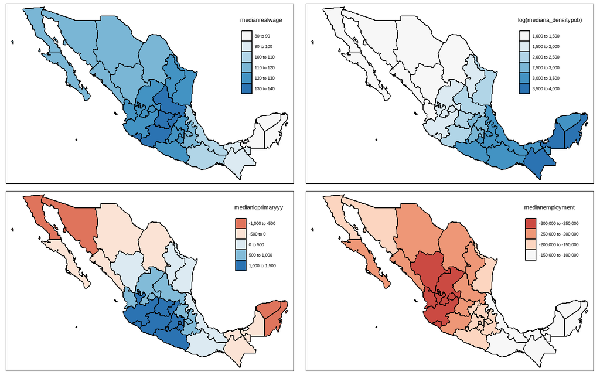

### *GWR - Local Regression Model Results 2006 - 2011*

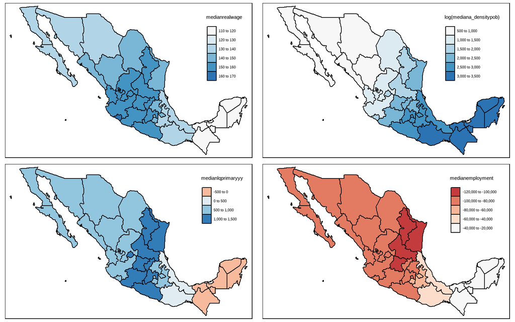

## **Conclusiones visualización de resultados**

En cuanto al locaton quotient primario se puede observar una gran diferencia entre ambos rangos de años. Del 2006 al 2011, se puede observar que el mayor impacto estaba en las regiones por el centro de México. Este efecto es positivo, lo que implicaría que el efecto de mayor concentración del sector primario es mayor en las regiones centrales. También se observa un efecto negativo pero en las regiones del sureste. Este patrón de datos cambia en los últimos años (2016-2021). En dónde se encuentra que en las regiones del norte y sureste, entre más concentración del sector primario, menor sería la IED nueva, y la intensidad de esta relación parece ser alta por la intensidad de los colores. Esto puede estar altamente relacionado con el territorio, principalmente en los estados del norte. Es decir, es posible que debido a que la industria requiere de ciertas condiciones geográficas para su éxito (clima, condiciones territoriales, recursos naturales, etc.), si la concentración es alta en zonas que no cumplen con estos requisitos los inversionistas pueden no estar interesados. Ciertamente, se puede observar que se ha convertido en un factor mucho más decisivo en los últimos años. Por último, se puede observar el grado de impacto de la variable de empleabilidad en las nuevas IED. Se mantiene el patrón de alguna manera pero la concentración cambia y el efecto cambia como de este a oeste.

Es importante mencionar que esta relación es negativa, lo que indica que a mayor empleabilidad menor es la IED nueva, y este efecto principalmente se observa en las regiones del centro y norte.